# R Notebook

# Set up Environment

```r
library(tidyverse)
library(GGally)
library(gtools)
library(scales)
library(ComplexHeatmap)
library(RColorBrewer)
```

file path

```r
# in windows
workdir <- "D:\\GoogleDrive\\DellXPS\\2018_DukeSpring\\BIOS706_Intro_Practice_of_Biostat_II\\HW05 Proj02 EDA"
```

```r
# in linux
workdir <- "/media/clint/Data/GitRepo/Statistics/BIOS706/HW05 Proj02 EDA"
#filePathData <- "/media/clint/Data/GoogleDrive/DellXPS/2018_DukeSpring/BIOS706_Intro_Practice_of_Biostat_II/HW05 Proj02 EDA"
```

# Import data

```r
dat_Team8 <- read.csv(file.path(workdir, "Team8.csv"))
dat_Team8 <- dat_Team8 %>% select(-team)
colnames(dat_Team8)[1] <- "sex"
head(dat_Team8)
```

|  | sex | education | race | mstat | dob | arthritis | backpain | heartprob | stroke | hbp | diabetes | lungprob | cancer | cogprob | depression | obesity | neuroprob | doctor |
| --- | --- | --- | --- | --- | --- | --- | --- | --- | --- | --- | --- | --- | --- | --- | --- | --- | --- | --- |
| 1 | 2 | 1 | 2 | 5 | 1932 | 1 | 0 | 0 | 1 | 0 | 0 | 0 | 0 | 0 | 0 | 0 | 0 | 3 |
| 2 | 1 | 3 | 1 | 5 | 1951 | 2 | 1 | 2 | 2 | 2 | 2 | 2 | 2 | 2 | 2 | 2 | 2 | 2 |
| 3 | 1 | 3 | 1 | 1 | 1949 | 2 | 2 | 2 | 1 | 2 | 2 | 2 | 2 | 2 | 2 | 2 | 2 | 4 |
| 4 | 2 | 3 | 1 | 4 | 1968 | 2 | 2 | 2 | 2 | 2 | 2 | 2 | 2 | 2 | 1 | 2 | 2 | 4 |
| 5 | 1 | 4 | 1 | 3 | 1978 | 0 | 0 | 0 | 0 | 0 | 0 | 0 | 0 | 0 | 0 | 0 | 1 | 3 |
| 6 | 2 | 3 | 1 | 5 | 1932 | 1 | 2 | 2 | 2 | 1 | 2 | 2 | 2 | 2 | 2 | 2 | 2 | 1 |

the colnames of the data

```r
cat(colnames(dat_Team8))
```

```
sex education race mstat dob arthritis backpain heartprob stroke hbp diabetes lungprob cancer cogprob depression obesity neuroprob doctor
```

change dob to age and remove NA values what to remove - education — remove NA - dob — remove 9997, 9999 - mstat — remove 9

```r
#dat_filter <- dat_Team8 %>%
#    mutate(age = 2018 - dob) %>%
#    filter(!(dob %in% c(9999, 9997))) %>%
#    filter(mstat != 9) %>%
#    na.omit()
#cat("Before filtered", nrow(dat_Team8), "\n")
#cat("After  filtered", nrow(dat_filter), "\n")
#head(dat_filter[, c("dob", "age")])
# start preprocessing
dat <- dat_Team8
# age
dat <- dat %>% mutate(age = 2018 - dob)
#head(dat_prep[, c("dob", "age")])
# mstat
# Marital Status: 1=Separated, 2=Divorced, 3=Married, 4=Single- never married, 5=Widowed
# dat$mstat2 <- c("Separated", "Divorced", "Married", "unmarried", "Widowed")[dat$mstat]
dat <- dat %>% filter(mstat != 9)
dat$mstat2 <- c("Separated/Divorced", "Separated/Divorced", "Married", "Never married", "Widowed")[dat$mstat]
dat$mstat2 <- factor(
    dat$mstat2,
    levels = c("Separated/Divorced", "Married", "Never married", "Widowed"))
# married vs unmarried
dat$mstat3 <- c("Unmarried", "Unmarried", "Married", "Unmarried", "Unmarried")[dat$mstat]
dat$mstat3 <- factor(
    dat$mstat3,
    levels = c("Unmarried", "Married"))
dat$sex2 <- c("Male", "Female")[dat$sex]
dat_prep <- dat
head(dat_prep[, c("mstat", "mstat2",  "mstat3", "dob", "age")], 10)
```

|  | mstat | mstat2 | mstat3 | dob | age |
| --- | --- | --- | --- | --- | --- |
| 1 | 5 | Widowed | Unmarried | 1932 | 86 |
| 2 | 5 | Widowed | Unmarried | 1951 | 67 |
| 3 | 1 | Separated/Divorced | Unmarried | 1949 | 69 |
| 4 | 4 | Never married | Unmarried | 1968 | 50 |
| 5 | 3 | Married | Married | 1978 | 40 |
| 6 | 5 | Widowed | Unmarried | 1932 | 86 |
| 7 | 2 | Separated/Divorced | Unmarried | 1947 | 71 |
| 8 | 3 | Married | Married | 1962 | 56 |
| 9 | 2 | Separated/Divorced | Unmarried | 1969 | 49 |
| 10 | 2 | Separated/Divorced | Unmarried | 1951 | 67 |

variables for disease

```r
disease <- c("arthritis", "backpain", "heartprob", "stroke", "hbp", "diabetes", "lungprob", "cancer", "cogprob", "depression", "obesity", "neuroprob")
print(disease)
```

```
 [1] "arthritis"  "backpain"   "heartprob"  "stroke"     "hbp"        "diabetes"   "lungprob"
 [8] "cancer"     "cogprob"    "depression" "obesity"    "neuroprob"
```

```r
print(length(disease))
```

```
[1] 12
```

**fix the disease condition of doctor 1, 2, 4 vs doctor 3** change Doctor 3 *(1 = Yes, 0 = No)* to Doctor 1, 2, 4 *(1 = Yes, 2 = No)*

```r
dat <- dat_prep
idx_doc3 <- dat$doctor == 3
idx_dis  <- which(colnames(dat) %in% disease)
dat[idx_doc3, idx_dis] <- ifelse(dat[idx_doc3, idx_dis] == 0, 2, 1)
dat_health12 <- dat
print(nrow(dat_health12))
```

```
[1] 1074
```

```r
head(dat_health12)
```

|  | sex | education | race | mstat | dob | arthritis | backpain | heartprob | stroke | hbp | diabetes | lungprob | cancer | cogprob | depression | obesity | neuroprob | doctor | age | mstat2 | mstat3 | sex2 |
| --- | --- | --- | --- | --- | --- | --- | --- | --- | --- | --- | --- | --- | --- | --- | --- | --- | --- | --- | --- | --- | --- | --- |
| 1 | 2 | 1 | 2 | 5 | 1932 | 1 | 2 | 2 | 1 | 2 | 2 | 2 | 2 | 2 | 2 | 2 | 2 | 3 | 86 | Widowed | Unmarried | Female |
| 2 | 1 | 3 | 1 | 5 | 1951 | 2 | 1 | 2 | 2 | 2 | 2 | 2 | 2 | 2 | 2 | 2 | 2 | 2 | 67 | Widowed | Unmarried | Male |
| 3 | 1 | 3 | 1 | 1 | 1949 | 2 | 2 | 2 | 1 | 2 | 2 | 2 | 2 | 2 | 2 | 2 | 2 | 4 | 69 | Separated/Divorced | Unmarried | Male |
| 4 | 2 | 3 | 1 | 4 | 1968 | 2 | 2 | 2 | 2 | 2 | 2 | 2 | 2 | 2 | 1 | 2 | 2 | 4 | 50 | Never married | Unmarried | Female |
| 5 | 1 | 4 | 1 | 3 | 1978 | 2 | 2 | 2 | 2 | 2 | 2 | 2 | 2 | 2 | 2 | 2 | 1 | 3 | 40 | Married | Married | Male |
| 6 | 2 | 3 | 1 | 5 | 1932 | 1 | 2 | 2 | 2 | 1 | 2 | 2 | 2 | 2 | 2 | 2 | 2 | 1 | 86 | Widowed | Unmarried | Female |

```r
head(dat_prep)
```

|  | sex | education | race | mstat | dob | arthritis | backpain | heartprob | stroke | hbp | diabetes | lungprob | cancer | cogprob | depression | obesity | neuroprob | doctor | age | mstat2 | mstat3 | sex2 |
| --- | --- | --- | --- | --- | --- | --- | --- | --- | --- | --- | --- | --- | --- | --- | --- | --- | --- | --- | --- | --- | --- | --- |
| 1 | 2 | 1 | 2 | 5 | 1932 | 1 | 0 | 0 | 1 | 0 | 0 | 0 | 0 | 0 | 0 | 0 | 0 | 3 | 86 | Widowed | Unmarried | Female |
| 2 | 1 | 3 | 1 | 5 | 1951 | 2 | 1 | 2 | 2 | 2 | 2 | 2 | 2 | 2 | 2 | 2 | 2 | 2 | 67 | Widowed | Unmarried | Male |
| 3 | 1 | 3 | 1 | 1 | 1949 | 2 | 2 | 2 | 1 | 2 | 2 | 2 | 2 | 2 | 2 | 2 | 2 | 4 | 69 | Separated/Divorced | Unmarried | Male |
| 4 | 2 | 3 | 1 | 4 | 1968 | 2 | 2 | 2 | 2 | 2 | 2 | 2 | 2 | 2 | 1 | 2 | 2 | 4 | 50 | Never married | Unmarried | Female |
| 5 | 1 | 4 | 1 | 3 | 1978 | 0 | 0 | 0 | 0 | 0 | 0 | 0 | 0 | 0 | 0 | 0 | 1 | 3 | 40 | Married | Married | Male |
| 6 | 2 | 3 | 1 | 5 | 1932 | 1 | 2 | 2 | 2 | 1 | 2 | 2 | 2 | 2 | 2 | 2 | 2 | 1 | 86 | Widowed | Unmarried | Female |

change Doctor 1, 2, 4 *(1 = Yes, 2 = No)* to Doctor 3 *(1 = Yes, 0 = No)*

```r
dat <- dat_prep
idx_doc3 <- dat$doctor == 3
idx_dis  <- which(colnames(dat) %in% disease)
dat[!idx_doc3, idx_dis] <- ifelse(dat[!idx_doc3, idx_dis] == 2, 0, 1)
dat_health10 <- dat
print(nrow(dat_health10))
```

```
[1] 1074
```

```r
head(dat_health10)
```

|  | sex | education | race | mstat | dob | arthritis | backpain | heartprob | stroke | hbp | diabetes | lungprob | cancer | cogprob | depression | obesity | neuroprob | doctor | age | mstat2 | mstat3 | sex2 |
| --- | --- | --- | --- | --- | --- | --- | --- | --- | --- | --- | --- | --- | --- | --- | --- | --- | --- | --- | --- | --- | --- | --- |
| 1 | 2 | 1 | 2 | 5 | 1932 | 1 | 0 | 0 | 1 | 0 | 0 | 0 | 0 | 0 | 0 | 0 | 0 | 3 | 86 | Widowed | Unmarried | Female |
| 2 | 1 | 3 | 1 | 5 | 1951 | 0 | 1 | 0 | 0 | 0 | 0 | 0 | 0 | 0 | 0 | 0 | 0 | 2 | 67 | Widowed | Unmarried | Male |
| 3 | 1 | 3 | 1 | 1 | 1949 | 0 | 0 | 0 | 1 | 0 | 0 | 0 | 0 | 0 | 0 | 0 | 0 | 4 | 69 | Separated/Divorced | Unmarried | Male |
| 4 | 2 | 3 | 1 | 4 | 1968 | 0 | 0 | 0 | 0 | 0 | 0 | 0 | 0 | 0 | 1 | 0 | 0 | 4 | 50 | Never married | Unmarried | Female |
| 5 | 1 | 4 | 1 | 3 | 1978 | 0 | 0 | 0 | 0 | 0 | 0 | 0 | 0 | 0 | 0 | 0 | 1 | 3 | 40 | Married | Married | Male |
| 6 | 2 | 3 | 1 | 5 | 1932 | 1 | 0 | 0 | 0 | 1 | 0 | 0 | 0 | 0 | 0 | 0 | 0 | 1 | 86 | Widowed | Unmarried | Female |

```r
dat_no_disease <- dat_Team8 %>%
    select(-c(arthritis, backpain, heartprob, stroke, hbp, diabetes,
              lungprob, cancer, cogprob, depression, obesity, neuroprob))
head(dat_no_disease, 3)
```

|  | sex | education | race | mstat | dob | doctor |
| --- | --- | --- | --- | --- | --- | --- |
| 1 | 2 | 1 | 2 | 5 | 1932 | 3 |
| 2 | 1 | 3 | 1 | 5 | 1951 | 2 |
| 3 | 1 | 3 | 1 | 1 | 1949 | 4 |

Note: Marital Status: 1=Separated, 2=Divorced, 3=Married, 4=Single- never married, 5=Widowed,

# calculate health index

```r
head(dat_health10)
```

[output not shown]

```r
dat <- dat_health10
idx_dis  <- which(colnames(dat) %in% disease)
dat_dis  <- dat[, idx_dis]
head(dat_dis)
```

|  | arthritis | backpain | heartprob | stroke | hbp | diabetes | lungprob | cancer | cogprob | depression | obesity | neuroprob |
| --- | --- | --- | --- | --- | --- | --- | --- | --- | --- | --- | --- | --- |
| 1 | 1 | 0 | 0 | 1 | 0 | 0 | 0 | 0 | 0 | 0 | 0 | 0 |
| 2 | 0 | 1 | 0 | 0 | 0 | 0 | 0 | 0 | 0 | 0 | 0 | 0 |
| 3 | 0 | 0 | 0 | 1 | 0 | 0 | 0 | 0 | 0 | 0 | 0 | 0 |
| 4 | 0 | 0 | 0 | 0 | 0 | 0 | 0 | 0 | 0 | 1 | 0 | 0 |
| 5 | 0 | 0 | 0 | 0 | 0 | 0 | 0 | 0 | 0 | 0 | 0 | 1 |
| 6 | 1 | 0 | 0 | 0 | 1 | 0 | 0 | 0 | 0 | 0 | 0 | 0 |

```r
dat <- dat_dis
health_idx <- apply(dat, 1, sum)
dat <- dat_health10
dat$health_idx <- health_idx
dat_health10_idx <- dat
dat <- dat_health12
dat$health_idx <- health_idx
dat_health12_idx <- dat
```

```r
head(dat_health10_idx)
```

|  | sex | education | race | mstat | dob | arthritis | backpain | heartprob | stroke | hbp | diabetes | lungprob | cancer | cogprob | depression | obesity | neuroprob | doctor | age | mstat2 | mstat3 | sex2 | health_idx |
| --- | --- | --- | --- | --- | --- | --- | --- | --- | --- | --- | --- | --- | --- | --- | --- | --- | --- | --- | --- | --- | --- | --- | --- |
| 1 | 2 | 1 | 2 | 5 | 1932 | 1 | 0 | 0 | 1 | 0 | 0 | 0 | 0 | 0 | 0 | 0 | 0 | 3 | 86 | Widowed | Unmarried | Female | 2 |
| 2 | 1 | 3 | 1 | 5 | 1951 | 0 | 1 | 0 | 0 | 0 | 0 | 0 | 0 | 0 | 0 | 0 | 0 | 2 | 67 | Widowed | Unmarried | Male | 1 |
| 3 | 1 | 3 | 1 | 1 | 1949 | 0 | 0 | 0 | 1 | 0 | 0 | 0 | 0 | 0 | 0 | 0 | 0 | 4 | 69 | Separated/Divorced | Unmarried | Male | 1 |
| 4 | 2 | 3 | 1 | 4 | 1968 | 0 | 0 | 0 | 0 | 0 | 0 | 0 | 0 | 0 | 1 | 0 | 0 | 4 | 50 | Never married | Unmarried | Female | 1 |
| 5 | 1 | 4 | 1 | 3 | 1978 | 0 | 0 | 0 | 0 | 0 | 0 | 0 | 0 | 0 | 0 | 0 | 1 | 3 | 40 | Married | Married | Male | 1 |
| 6 | 2 | 3 | 1 | 5 | 1932 | 1 | 0 | 0 | 0 | 1 | 0 | 0 | 0 | 0 | 0 | 0 | 0 | 1 | 86 | Widowed | Unmarried | Female | 2 |

```r
head(dat_health12_idx)
```

|  | sex | education | race | mstat | dob | arthritis | backpain | heartprob | stroke | hbp | diabetes | lungprob | cancer | cogprob | depression | obesity | neuroprob | doctor | age | mstat2 | mstat3 | sex2 | health_idx |
| --- | --- | --- | --- | --- | --- | --- | --- | --- | --- | --- | --- | --- | --- | --- | --- | --- | --- | --- | --- | --- | --- | --- | --- |
| 1 | 2 | 1 | 2 | 5 | 1932 | 1 | 2 | 2 | 1 | 2 | 2 | 2 | 2 | 2 | 2 | 2 | 2 | 3 | 86 | Widowed | Unmarried | Female | 2 |
| 2 | 1 | 3 | 1 | 5 | 1951 | 2 | 1 | 2 | 2 | 2 | 2 | 2 | 2 | 2 | 2 | 2 | 2 | 2 | 67 | Widowed | Unmarried | Male | 1 |
| 3 | 1 | 3 | 1 | 1 | 1949 | 2 | 2 | 2 | 1 | 2 | 2 | 2 | 2 | 2 | 2 | 2 | 2 | 4 | 69 | Separated/Divorced | Unmarried | Male | 1 |
| 4 | 2 | 3 | 1 | 4 | 1968 | 2 | 2 | 2 | 2 | 2 | 2 | 2 | 2 | 2 | 1 | 2 | 2 | 4 | 50 | Never married | Unmarried | Female | 1 |
| 5 | 1 | 4 | 1 | 3 | 1978 | 2 | 2 | 2 | 2 | 2 | 2 | 2 | 2 | 2 | 2 | 2 | 1 | 3 | 40 | Married | Married | Male | 1 |
| 6 | 2 | 3 | 1 | 5 | 1932 | 1 | 2 | 2 | 2 | 1 | 2 | 2 | 2 | 2 | 2 | 2 | 2 | 1 | 86 | Widowed | Unmarried | Female | 2 |

```r
dat <- dat_health12_idx
dat <- dat %>% select(health_idx, mstat, mstat2, mstat3)
head(dat)
```

|  | health_idx | mstat | mstat2 | mstat3 |
| --- | --- | --- | --- | --- |
| 1 | 2 | 5 | Widowed | Unmarried |
| 2 | 1 | 5 | Widowed | Unmarried |
| 3 | 1 | 1 | Separated/Divorced | Unmarried |
| 4 | 1 | 4 | Never married | Unmarried |
| 5 | 1 | 3 | Married | Married |
| 6 | 2 | 5 | Widowed | Unmarried |

output the file

```r
write.csv(dat_health10_idx, file.path(workdir, "dat_health10_idx.csv"), row.names = FALSE)
write.csv(dat_health12_idx, file.path(workdir, "dat_health12_idx.csv"), row.names = FALSE)
```

# plot health index (number of health deleterious conditions)

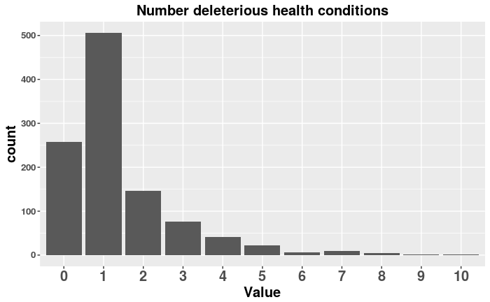

```r
dat <- dat_health10_idx
dat$health_idx <- as.character(dat$health_idx)
dat$health_idx <- factor(dat$health_idx, levels = 0:12)
gp <-  ggplot(dat, aes(x = health_idx))
gp <- gp + geom_bar(stat = "count") +
    ggtitle("Number deleterious health conditions") +
    xlab("Value") +
    #ylab("Number") +
    theme(
        plot.title  = element_text(size=15, face = "bold", hjust = 0.5),
        axis.title  = element_text(size=15, face="bold"),
        axis.text.y = element_text(size=10, face="bold"),
        axis.text.x = element_text(size=15, face="bold"))
            #angle=90, hjust=1, vjust=0.4))
gp
```

```r
ggsave("Distribution of Health Idx.png",
       plot = gp, dpi = 300, height = 5, width = 5)
```

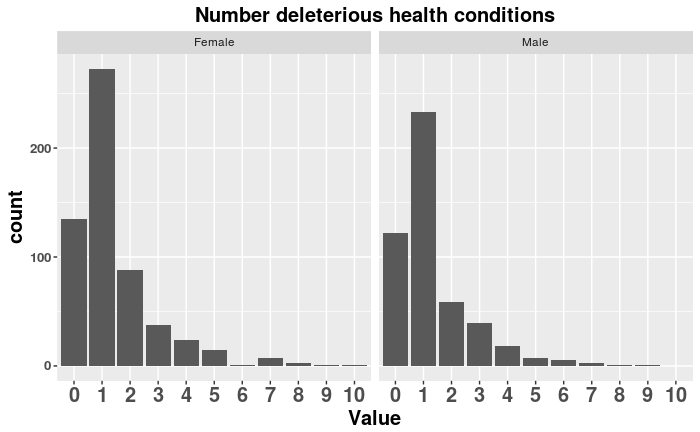

```r
dat <- dat_health10_idx
dat$health_idx <- as.character(dat$health_idx)
dat$health_idx <- factor(dat$health_idx, levels = 0:12)
gp <-  ggplot(dat, aes(x = health_idx))
gp <- gp + geom_bar(stat = "count") +
    ggtitle("Number deleterious health conditions") +
    xlab("Value") +
    #ylab("Number") +
    theme(
        plot.title  = element_text(size=15, face = "bold", hjust = 0.5),
        axis.title  = element_text(size=15, face="bold"),
        axis.text.y = element_text(size=10, face="bold"),
        axis.text.x = element_text(size=15, face="bold")) +
            #angle=90, hjust=1, vjust=0.4))
    facet_wrap(~sex2)
gp
```

```r
ggsave("Distribution of Health Idx_gender.png",
       plot = gp, dpi = 300, height = 5, width = 10)
```

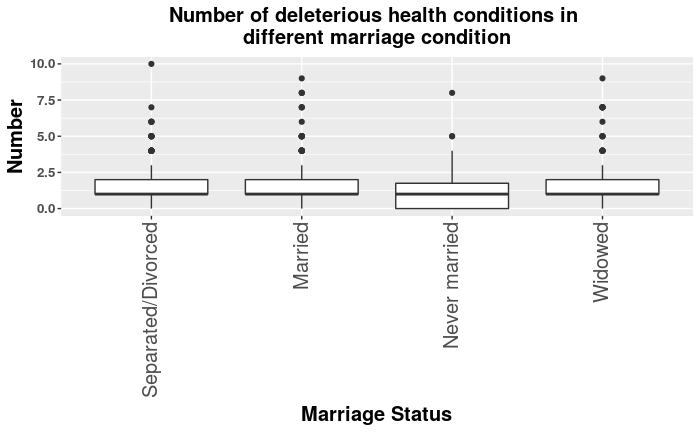

```r
dat <- dat_health10_idx
gp <-  ggplot(dat, aes(y = health_idx, x = mstat2))
gp <- gp +
    geom_boxplot() +
    ggtitle("Number of deleterious health conditions in \ndifferent marriage condition") +
    xlab("Marriage Status") +
    ylab("Number") +
    theme(
        plot.title  = element_text(size=15, face = "bold", hjust = 0.5),
        axis.title  = element_text(size=15, face="bold"),
        axis.text.y = element_text(size=10, face="bold"),
        axis.text.x = element_text(size=15, #face="bold",
            angle=90, hjust=1, vjust=0.4))
gp
```

```r
ggsave("Boxplot of Health Idx.png",
       plot = gp, dpi = 300, height = 7, width = 5)
```

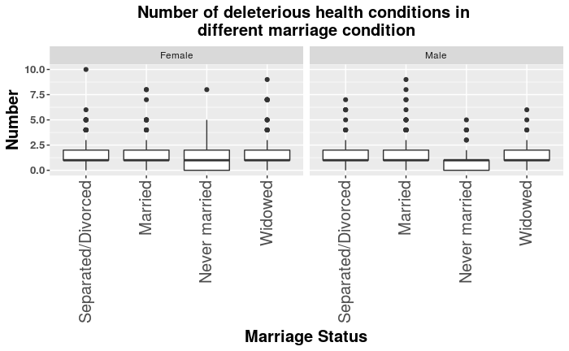

```r
dat <- dat_health10_idx
gp <-  ggplot(dat, aes(y = health_idx, x = mstat2))
gp <- gp +
    geom_boxplot() +
    ggtitle("Number of deleterious health conditions in \ndifferent marriage condition") +
    xlab("Marriage Status") +
    ylab("Number") +
    facet_wrap(~sex2) +
    theme(
        plot.title  = element_text(size=15, face = "bold", hjust = 0.5),
        axis.title  = element_text(size=15, face="bold"),
        axis.text.y = element_text(size=10, face="bold"),
        axis.text.x = element_text(size=15, #face="bold",
            angle=90, hjust=1, vjust=0.4))
gp
```

```r
ggsave("Boxplot of Health Idx gender.png",
       plot = gp, dpi = 300, height = 7, width = 8)
```

# Wilcoxin Test

```r
tmp <- split(dat$health_idx, dat$mstat2)
print(tmp)
```

```
$`Separated/Divorced`
  [1]  1  0  0  0  2  1  1  1  3  0  0  1  4  3  1  1  1  1  1  1  0  1  0  1  1  1  1  1  1  1  1  5
 [33]  2  2  1  0  0  5  4  0  1  0  1  0  1  0  4  5  1  1  2  2  1  0  2  1  5  2  1  1  1  2  1  1
 [65]  6  3  1  2  0  4  1  1  1  1  2  2  1  3  4  1  1  3  0  0  2  0  1  1  0  5  2  3  1  6  4  1
 [97]  3  3  0  0  2  1  0  0  1  1  1  0  0  1  0  3  2  2  5  1  2  0  1  1  1  1  0  0  1  4  1  0
[129]  4  0  4  2  1  7  1  1  1  2  2  4  1  2  2  1  1  1  3  1  0  1  1  0  1  2  0  1  4  1  1  1
[161]  0  1  2  2  2  0  0  2  1  3  1  1  0  2  1  2  1  3  1  1  2  1  1  1  3  1  1  1  2  1  1  1
[193]  3  1  0  1  1  1  0  1  0  1  1  3  1  4  1  1  3  2  4  0  2  2 10  1  1  6  6  4  1  0  1  1
[225]  1  1  5  2  3  3  2  1  3  1  1  3  3  1

$Married
  [1] 1 0 5 1 1 2 0 1 1 5 0 1 0 5 0 3 1 1 1 3 1 0 1 3 0 0 0 1 2 1 2 2 1 6 0 0 5 0 0 2 1 3 2 3 4 1 4 2 1
 [50] 3 1 1 2 1 4 1 1 1 1 1 1 3 0 7 5 1 1 1 1 4 0 0 2 2 1 0 0 1 3 0 1 2 4 3 1 0 1 1 1 1 2 1 0 0 0 0 1 1
 [99] 3 1 5 0 1 2 0 0 0 2 0 2 1 1 1 0 1 1 3 1 1 1 1 0 1 1 1 1 1 0 1 3 1 2 1 1 1 0 0 1 1 1 0 1 0 1 3 0 1
[148] 1 0 1 1 0 1 1 2 1 1 1 2 1 2 1 1 1 4 1 0 1 1 1 2 3 0 1 3 1 1 3 3 1 1 2 1 0 1 1 3 7 1 1 1 2 4 4 0 0
```

[output cut: 18 more lines]

```r
wilcox.test(x = tmp$Married, y = tmp$`Separated/Divorced`, alternative = "two.sided",,  correct=F)
```

```
    Wilcoxon rank sum test

data:  tmp$Married and tmp$`Separated/Divorced`
W = 46142, p-value = 0.02367
alternative hypothesis: true location shift is not equal to 0
```

```r
res
```

[output not shown]

```r
wilcox.test(x = tmp$Married, y = tmp$Widowed, alternative = "two.sided",,  correct=F) # paired=F, exact=T,
```

```
    Wilcoxon rank sum test

data:  tmp$Married and tmp$Widowed
W = 39820, p-value = 0.4471
alternative hypothesis: true location shift is not equal to 0
```

# Explore Variables

**list of variables** sex education race mstat dob arthritis backpain heartprob stroke hbp diabetes lungprob cancer cogprob depression obesity neuroprob doctor

## All the unique values

```r
lapply(dat_Team8, unique)
```

## Count the covariates

```r
#dat <- dat_Team8 %>%
#    select(-c(arthritis, backpain, heartprob, stroke, hbp, diabetes,
#              lungprob, cancer, cogprob, depression, obesity, neuroprob))
dat <- dat_no_disease
head(dat, 3)
```

count the covariates

```r
lapply(dat, table, exclude = NULL)
```

## Year / Age

```r
cat(sort(unique(dat$dob)))
```

```r
dob <- dat_no_disease$dob
cat(paste("1931-1940", sum((1931 <= dob) & (dob <= 1940))), "\n")
cat(paste("1941-1950", sum((1941 <= dob) & (dob <= 1950))), "\n")
cat(paste("1951-1960", sum((1951 <= dob) & (dob <= 1960))), "\n")
cat(paste("1961-1970", sum((1961 <= dob) & (dob <= 1970))), "\n")
cat(paste("1971-1980", sum((1971 <= dob) & (dob <= 1980))), "\n")
cat(paste("1981-1990", sum((1981 <= dob) & (dob <= 1990))), "\n")
cat(paste("1991-2000", sum((1991 <= dob) & (dob <= 2000))))
```

```r
dat <- dat_health10
tapply(dat$age, dat$mstat2, range)
```

[output not shown]

## count each covariates with mstat

```r
lapply(dat, function(x){table(x, dat$mstat)})
```

# pairwise comparison

```r
#dat <- dat_Team8 %>% select(-c(arthritis, backpain, heartprob, stroke, hbp, diabetes, lungprob, cancer, cogprob, depression, obesity, neuroprob))
#head(dat, 3)
dat <- dat_no_disease
head(dat)
```

```r
dat$mstat <- as.character(dat$mstat)
gp <- ggpairs(dat,
        aes(colour = mstat, alpha = 0.4),
        diag=list(continuous="bar"))
#for (idx in 1:4){
#    gp[idx, idx] <- gp[idx, idx] + geom_histogram(bins = 12)
#} # end for
gp
```

# Compare mstat and proportion of each disease

## with inforamtion of doctor

```r
dat <- dat_health12
dat <- dat %>% select(
    mstat2, doctor,
    arthritis, backpain, heartprob, stroke, hbp, diabetes, lungprob,
    cancer, cogprob, depression, obesity, neuroprob)

dat <- dat %>%
    gather(disease, health_condition, -mstat2, -doctor) %>%
    group_by(disease, health_condition, mstat2, doctor) %>%
    summarize(Count = n())
dat$health_condition <- factor(as.character(dat$health_condition), levels = c("2", "1"))
#dat$mstat2 <- c("Separated", "Divorced", "Married", "unmarried", "Widowed")[dat$mstat]
dat$doctor <- paste("Doctor", dat$doctor)
head(dat)
```

```r
gp <- ggplot(dat, aes(x=disease, y=Count, fill=health_condition))
gp <- gp +
    #geom_bar(stat="identity") +
    geom_bar(stat="identity", position = "fill") +
    scale_y_continuous(labels = percent_format()) +
    scale_fill_manual(values = c("#b3cde3", "#fbb4ae")) +
    #scale_fill_manual(values = c("#b3cde3", "#b3cde3", "#fbb4ae")) +
        # red, blue
        # blue   #b3cde3
        # green  #ccebc5
        # red    #fbb4ae

    facet_grid(doctor~mstat2) +
    labs(fill="Health Condition") +
    xlab("Disease") +
    ylab("Proportion") +
    #coord_flip() +
    theme(
        plot.title  = element_text(hjust = 0.5),
        axis.title  = element_text(size=20, face="bold"),
        axis.text.y = element_text(size=10, face="bold"),
        axis.text.x = element_text(size=5, face="bold",
            angle=90, hjust=1, vjust=0.4))
print(gp)
```

```r
ggsave("Disease Proportion vs Marriage vs Doctor.png",
       plot = gp, dpi = 300, height = 10, width = 10)
```

## remove the doctor information to plot the spline plot

```r
dat <- dat_health12
dat <- dat %>% select(
    mstat2,
    arthritis, backpain, heartprob, stroke, hbp, diabetes, lungprob,
    cancer, cogprob, depression, obesity, neuroprob)

dat <- dat %>%
    gather(disease, health_condition, -mstat2) %>%
    group_by(disease, health_condition, mstat2) %>%
    summarize(Count = n())
dat$health_condition <- factor(as.character(dat$health_condition), levels = c("2", "1"))
#dat$mstat2 <- c("Separated", "Divorced", "Married", "unmarried", "Widowed")[dat$mstat]
head(dat)
```

```r
gp <- ggplot(dat, aes(x=disease, y=Count, fill=health_condition))
gp <- gp +
    #geom_bar(stat="identity") +
    geom_bar(stat="identity", position = "fill") +
    scale_y_continuous(labels = percent_format()) +
    scale_fill_manual(values = c("#b3cde3", "#fbb4ae")) +
    #scale_fill_manual(values = c("#b3cde3", "#b3cde3", "#fbb4ae")) +
        # red, blue
        # blue   #b3cde3
        # green  #ccebc5
        # red    #fbb4ae

    facet_grid(~mstat2) +
    labs(fill="Health Condition") +
    xlab("Disease") +
    ylab("Proportion") +
    #coord_flip() +
    theme(
        plot.title  = element_text(hjust = 0.5),
        axis.title  = element_text(size=20, face="bold"),
        axis.text.y = element_text(size=5, face="bold"),
        axis.text.x = element_text(size=10, face="bold",
            angle=90, hjust=1, vjust=0.4))
print(gp)
```

```r
ggsave("Disease Proportion vs Marriage.png",
       plot = gp, dpi = 300, height = 3, width = 10)
```

# Visualize health data

```r
dat <- dat_health12
idx_dis <- which(colnames(dat) %in% disease)
mat <- dat[,idx_dis] %>% as.matrix
head(mat)
```

```r
head(dat[, -idx_dis])
```

```r
colnames(dat[, -idx_dis])
```

```r
range(dat$age)
```

```r
# Annocation: mstat
color <- brewer.pal(n = 5, name = "Set3")
names(color) <- c("1", "2", "3", "4", "5")
ha1 = HeatmapAnnotation(
    df = data.frame(marriage = dat$mstat),
    col = list(marriage = color),
    which = "row",
    width = unit(1, "cm"),
    show_legend = TRUE)

# Annocation: doctor
color <- c("red", "green", "blue", "grey")
names(color) <- c("1", "2", "3", "4")
ha2 = HeatmapAnnotation(
    df = data.frame(doctor = dat$doctor),
    col = list(doctor = color),
    which = "row",
    width = unit(1, "cm"),
    show_legend = TRUE)

# Annocation: sex
#   1 = Male
#   2 = Female
color <- c("#b3cde3", "#fbb4ae") # blue, red
names(color) <- c("1", "2")
ha3 = HeatmapAnnotation(
    df = data.frame(sex = dat$sex),
    col = list(sex = color),
    which = "row",
    width = unit(1, "cm"),
    show_legend = TRUE)

# Annocation: race
#   1 = White
#   2 = Black
#   3 = Asian
#   4 = Other
color <- c("#ffffb3", "#e5c494", "#fdb462", "#d9d9d9") # yellow, brown, orange, grey
names(color) <- c("1", "2", "3", "4")
ha3 = HeatmapAnnotation(
    df = data.frame(race = dat$race),
    col = list(race = color),
    which = "row",
    width = unit(1, "cm"),
    show_legend = TRUE)

# Annocation: age
#color <- brewer.pal(n = 7, name = "PuBu")[-1] # purple to blue scale
#color <- colorRampPalette(color)(90 - 20 + 1)
#names(color) <- as.character(20:90)
ha4 = HeatmapAnnotation(
    #df = data.frame(age = dat$age),
    points = row_anno_barplot(dat$age),
    #col = list(age = color),
    which = "row",
    width = unit(3, "cm"))
    #show_legend = TRUE)

# Heatmap Matrix
ht = Heatmap(
    mat,
    name = "health status",
    column_title = "Health Condition",
    col = c("#e41a1c", "#b3e2cd"), # red, light green
    #cluster_rows=FALSE,
    cluster_rows=TRUE,
    cluster_columns=FALSE,
    show_row_names = FALSE)

# Plot the result
ht_list = ht + ha1 + ha2 + ha3 + ha4
draw(ht_list)
```

## sort by mstat

```r
dat <- dat_health12
dat <- dat %>% arrange(mstat, sex, education, age)
idx_dis <- which(colnames(dat) %in% disease)
mat <- dat[,idx_dis] %>% as.matrix
#head(mat)
#head(dat)
```

```r
# Annocation: mstat
color <- brewer.pal(n = 5, name = "Set3")
names(color) <- c("1", "2", "3", "4", "5")
ha1 = HeatmapAnnotation(
    df = data.frame(marriage = dat$mstat),
    col = list(marriage = color),
    which = "row",
    width = unit(1, "cm"),
    show_legend = TRUE)

# Annocation: doctor
#color <- c("red", "green", "blue", "grey")
#names(color) <- c("1", "2", "3", "4")
color <- brewer.pal(n = 4, name = "Set1")
names(color) <- c("1", "2", "3", "4")
ha2 = HeatmapAnnotation(
    df = data.frame(doctor = dat$doctor),
    col = list(doctor = color),
    which = "row",
    width = unit(1, "cm"),
    show_legend = TRUE)

# Annocation: sex
#   1 = Male
#   2 = Female
color <- c("#b3cde3", "#fbb4ae") # blue, red
names(color) <- c("1", "2")
ha3 = HeatmapAnnotation(
    df = data.frame(sex = dat$sex),
    col = list(sex = color),
    which = "row",
    width = unit(1, "cm"),
    show_legend = TRUE)

# Annocation: race
#   1 = White
#   2 = Black
#   3 = Asian
#   4 = Other
color <- c("#ffffb3", "#e5c494", "#fdb462", "#d9d9d9") # yellow, brown, orange, grey
names(color) <- c("1", "2", "3", "4")
ha3 = HeatmapAnnotation(
    df = data.frame(race = dat$race),
    col = list(race = color),
    which = "row",
    width = unit(1, "cm"),
    show_legend = TRUE)

# Annocation: age
#color <- brewer.pal(n = 7, name = "PuBu")[-1] # purple to blue scale
#color <- colorRampPalette(color)(90 - 20 + 1)
#names(color) <- as.character(20:90)
ha4 = HeatmapAnnotation(
    #df = data.frame(age = dat$age),
    points = row_anno_barplot(dat$age),
    #col = list(age = color),
    which = "row",
    width = unit(3, "cm"))
    #show_legend = TRUE)

# Heatmap Matrix
ht = Heatmap(
    mat,
    name = "health status",
    column_title = "Health Condition",
    col = c("#e41a1c", "#b3e2cd"), # red, light green
    cluster_rows=FALSE,
    #cluster_rows=TRUE,
    cluster_columns=FALSE,
    show_row_names = FALSE)

# Plot the result
ht_list = ht + ha1 + ha2 + ha3 + ha4
draw(ht_list)
```

```r
#pdf(filePlot, width = WIDTH, height = 10)
pdf(file.path(workdir, "Heatmap Health Condition.pdf"), width = 10, height = 10)
ht_list = ht + ha1 + ha2 + ha3 + ha4
draw(ht_list)
dev.off()
```

# Visualize the distribution of every variables

```r
dat <- dat_Team8 %>% select(-c(arthritis, backpain, heartprob, stroke, hbp, diabetes, lungprob, cancer, cogprob, depression, obesity, neuroprob))
head(dat, 3)
```

```r
colnames(dat)
```

sex vs marriage

```r
plot(jitter(sex, 0.5) ~ jitter(mstat, 1.5), data = dat, pch = 20,
     ylab = "sex", xlab = "marriage")
#axis(2, labels=c(1, 2))
```

```r
plot(jitter(race, 0.5) ~ jitter(mstat, 1.5), data = dat, pch = 20,
     ylab = "race", xlab = "marriage")
#axis(2, labels=c(1, 2))
```

# Analysis: Proportion test — marriage vs disease

```r
dat <- dat_health10
idx_dis <- which(colnames(dat) %in% c("mstat2", disease))
dat <- dat[, idx_dis]
head(dat)
```

Marital Status: 1=Separated, 2=Divorced, 3=Married, 4=Single- never married, 5=Widowed,

```r
tmp <- dat %>% gather(disease, condition, -mstat2)
tmp <- tmp %>% group_by(disease, mstat2) %>% summarize(freq = sum(condition)/n())
tmp <- tmp %>% spread(mstat2, freq)
#tmp <- tmp %>% set_names(c(
#    "Disease", "Separated", "Divorced",
#    "Married", "Unmarried", "Widowed"))
colnames(tmp)[1] <- "Disease"
dat_prob <- tmp
dat_prob
```

```r
gp <- ggparcoord(dat_prob, columns = 2:5, groupColumn = 'Disease', scale = 'globalminmax') +
    ggtitle("Proportion of Each Disease in Different Marriage Status") +
    xlab("Marriage Status") +
    ylab("Proportion") +
    theme(
        plot.title  = element_text(size=15, face = "bold", hjust = 0.5),
        axis.title  = element_text(size=15, face="bold"),
        axis.text.y = element_text(size=10, face="bold"),
        axis.text.x = element_text(size=10, #face="bold",
            angle=90, hjust=1, vjust=0.4))
gp
```

```r
ggsave("Disease Proportion vs Marriage_parallel.png",
       plot = gp, dpi = 300, height = 5, width = 7)
```

```r
tmp <- dat_prob[, -1] %>% gather(mstat, prob)
tmp$mstat <- factor(tmp$mstat, levels = colnames(dat_prob[,-1]))
gp  <- tmp %>%
    ggplot(aes(x = mstat, y = prob)) +
    geom_boxplot() +
    ggtitle("Proportion of Each Disease in Different Marriage Status") +
    xlab("Marriage Status") +
    ylab("Proportion") +
    theme(
        plot.title  = element_text(size=15, face = "bold", hjust = 0.5),
        axis.title  = element_text(size=15, face="bold"),
        axis.text.y = element_text(size=10, face="bold"),
        axis.text.x = element_text(size=15, #face="bold",
            angle=90, hjust=1, vjust=0.4))
gp
```

```r
ggsave("Disease Proportion vs Marriage_boxplot.png",
       plot = gp, dpi = 300, height = 5, width = 7)
```

```r
tmp <- table(dat_health10$mstat2)
num_cat <- as.numeric(tmp)
names(num_cat) <- names(tmp)
print(num_cat)
```

```r
tmp <- data.frame(
    mstat2 = colnames(dat_prob[,-1]),
    value = num_cat)
tmp$mstat2 <- factor(tmp$mstat2, levels = colnames(dat_prob[,-1]))
gp <- tmp %>%
    ggplot(aes(x = mstat2, y = value)) +
    geom_bar(stat = "identity") +
    ggtitle("Number of Patients in Different Marriage Status") +
    xlab("Marriage Status") +
    ylab("Number") +
    theme(
        plot.title  = element_text(size=15, face = "bold", hjust = 0.5),
        axis.title  = element_text(size=15, face="bold"),
        axis.text.y = element_text(size=10, face="bold"),
        axis.text.x = element_text(size=15, #face="bold",
            angle=90, hjust=1, vjust=0.4))
gp
```

```r
tmp <- data.frame(marriage = 2, others = c(1,3,4))
group_idx <- as.matrix(tmp)
print(group_idx)
```

```r
tmp <- as.matrix(dat_prob[,-1])
res_prob_test <- apply(group_idx, 1, function(idx){
    #print(idx)
    #print(colnames(tmp[,idx]))

    res <- apply(tmp[, idx], 1, function(prob) {
        #print(prob)
        res <- prop.test(
            x = prob * num_cat[idx],
            n = num_cat[idx],
            alternative = 'less',
            correct = FALSE)
        return(res)
    }) # end innter lapply

    return(res)
}) # end outer apply

names(res_prob_test) <- paste("marriage_vs", colnames(tmp)[c(1, 3, 4)], sep = "_")
for(idx in seq_along(res_prob_test)){
    names(res_prob_test[[idx]]) <- as.character(dat_prob$Disease)
}
#print(res_prob_test)
```

```r
tmp <- lapply(res_prob_test, function(group){
    unlist(lapply(group, function(x){
        x$p.value
    })) # end inner lapply
}) # end outer lapply
res_test_pval <- as.data.frame(tmp)
```

```r
ht <- Heatmap(
    t(res_test_pval),
    name = "P value",
    column_title = "Two Sample Prop Test P.value",
    col = c("#e41a1c", "#b3e2cd"), # red, light green
    cluster_rows=FALSE,
    cluster_columns=FALSE,
    show_row_names = TRUE,
    row_names_side = "left")
    #column_names_gp = gpar(fontsize = 10))
draw(ht, padding = unit(10, "mm"))
```

convert pvalue to binary

```r
res_pval_isless05 <- ifelse(res_test_pval <= 0.05, "yes", "no")
ht <- Heatmap(
    t(res_pval_isless05),
    name = "Is Significant",
    column_title = "Two Sample Prop Test P.value",
    col = c("grey70", "grey10"),
    cluster_rows=FALSE,
    cluster_columns=FALSE,
    show_row_names = TRUE,
    row_names_side = "left")
draw(ht, padding = unit(10, "mm"))
```

# freq: marriage vs disease vs gender

```r
dat <- dat_Team8
dat <- dat %>%
    filter(mstat != 9) %>%
    select(sex, doctor, mstat, arthritis, backpain, heartprob, stroke, hbp, diabetes, lungprob, cancer, cogprob, depression, obesity, neuroprob)
head(dat)
```

```r
idx <- dat$doctor != 3
dat[idx, c(-1, -2, -3)] <- ifelse(dat[idx, c(-1, -2, -3)] == 2, 0, 1)
head(dat)
```

```r
dat <- dat %>% gather(disease, condition, -doctor, -mstat, -sex)
dat <- dat %>%
    group_by(disease, sex, mstat) %>%
    summarize(freq = sum(condition)/n())
dat <- dat %>% spread(mstat, freq)
head(dat)
```

```r
tmp_male <- dat %>% filter(sex == 1)
tmp_male
```

```r
boxplot(tmp_male[, -c(1, 2)])
```

```r
tmp_female <- dat %>% filter(sex == 2)
tmp_female
```

```r
boxplot(tmp_female[, -c(1, 2)])
```

# health data

```r
dat %>% filter(doctor == 3) %>% head()
```

```r
#tmp# <- dat[, c("arthritis", "backpain", "heartprob", "stroke", "hbp", "diabetes", "lungprob", "cancer", "cogprob", "depression", "obesity", "neuroprob"]
#)]
tmp <- dat[, 6:17]
head(tmp)
```

# marriage data

```r
table(dat$mstat)
```

# variable: education

Education: 1=Less than High School, 2=High School graduate, 3= Some College, 4=College Graduate, 5=Post graduate

```r
table(dat$education)
```

# Variable: race

Race: 1=White, 2=Black, 3=Asian, 4=Other

```r
unique(dat$race)
```

```r
sum(is.na(dat$race))
```

# variable: gender

Gender: 1=Male, 2=Female

```r
unique(dat$SEX)
```

```r
table(dat$SEX)
```

```r
sum(is.na(dat$SEX))
```

# Variable: age

```r
sum(dat$dob > 2020)
```

```r
unique(dat$dob[dat$dob > 2020])
#nrow(dat)
```

```r
tmp <- dat %>% filter(dob < 2018)
hist(2018 - tmp$dob)
```

Number of patients from different regions

```r
table(dat$doctor)
```

```r
boxplot(2018 - tmp$dob)
```

```r
hist(dat$dob, breaks = sequence())
#head(dat$dob)
```

```r
lapply(tmp, function(x){
    tapply(x, dat$doctor, function(x){table(x)})
})
```